# EasyVisa Project

### XGBoost Classifier

```
Training performance:
    Accuracy    Recall  Precision        F1
0  0.838753  0.931419   0.843482  0.885272
Testing performance:
    Accuracy    Recall  Precision        F1
0  0.733255  0.860725   0.767913  0.811675
```

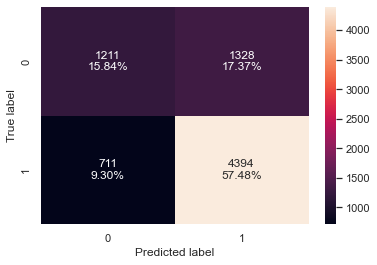

```python
#Fitting the model
xgb_classifier = XGBClassifier(random_state=1, eval_metric='logloss')
xgb_classifier.fit(X_train,y_train)

#Calculating different metrics
xgb_classifier_model_train_perf=model_performance_classification_sklearn(xgb_classifier,X_train,y_train)
print("Training performance:\n",xgb_classifier_model_train_perf)
xgb_classifier_model_test_perf=model_performance_classification_sklearn(xgb_classifier,X_test,y_test)
print("Testing performance:\n",xgb_classifier_model_test_perf)

#Creating confusion matrix
confusion_matrix_sklearn(xgb_classifier,X_test,y_test)
```

- xgboost classifier is overfitting the training data.
- Let's try hyperparameter tuning and see if the model performance improves.

```python
# Choose the type of classifier.
xgb_tuned = XGBClassifier(random_state=1, eval_metric='logloss')

# Grid of parameters to choose from
parameters = {
    "n_estimators": [10,30,50],
    "scale_pos_weight":[1,2,5],
    "subsample":[0.7,0.9,1],
    "learning_rate":[0.05, 0.1,0.2],
    "colsample_bytree":[0.7,0.9,1],
    "colsample_bylevel":[0.5,0.7,1]
}

# Type of scoring used to compare parameter combinations
scorer = metrics.make_scorer(metrics.f1_score)

# Run the grid search
grid_obj = GridSearchCV(xgb_tuned, parameters,scoring=scorer,cv=5,verbose =2,n_jobs=-1)
grid_obj = grid_obj.fit(X_train, y_train)

# Set the clf to the best combination of parameters
xgb_tuned = grid_obj.best_estimator_

# Fit the best algorithm to the data.
xgb_tuned.fit(X_train, y_train)
```

```
Fitting 5 folds for each of 729 candidates, totalling 3645 fits
```

```
XGBClassifier(base_score=0.5, booster='gbtree', callbacks=None,
              colsample_bylevel=0.5, colsample_bynode=1, colsample_bytree=1,
              early_stopping_rounds=None, enable_categorical=False,
              eval_metric='logloss', gamma=0, gpu_id=-1,
              grow_policy='depthwise', importance_type=None,
              interaction_constraints='', learning_rate=0.05, max_bin=256,
              max_cat_to_onehot=4, max_delta_step=0, max_depth=6, max_leaves=0,
              min_child_weight=1, missing=nan, monotone_constraints='()',
              n_estimators=30, n_jobs=0, num_parallel_tree=1, predictor='auto',
              random_state=1, reg_alpha=0, reg_lambda=1, ...)
```

```
Training performance:
    Accuracy   Recall  Precision        F1
0  0.759587  0.88374   0.783858  0.830808
Testing performance:
    Accuracy    Recall  Precision        F1
0  0.745683  0.876004   0.773301  0.821455
```

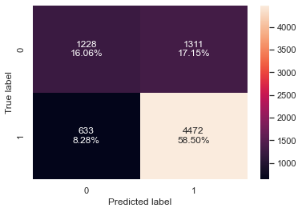

```python
#Calculating different metrics
xgb_tuned_model_train_perf=model_performance_classification_sklearn(xgb_tuned,X_train,y_train)
print("Training performance:\n",xgb_tuned_model_train_perf)
xgb_tuned_model_test_perf=model_performance_classification_sklearn(xgb_tuned,X_test,y_test)
print("Testing performance:\n",xgb_tuned_model_test_perf)

#Creating confusion matrix
confusion_matrix_sklearn(xgb_tuned,X_test,y_test)
```

Tuned model has a higher F1 score and also the precision is increased.

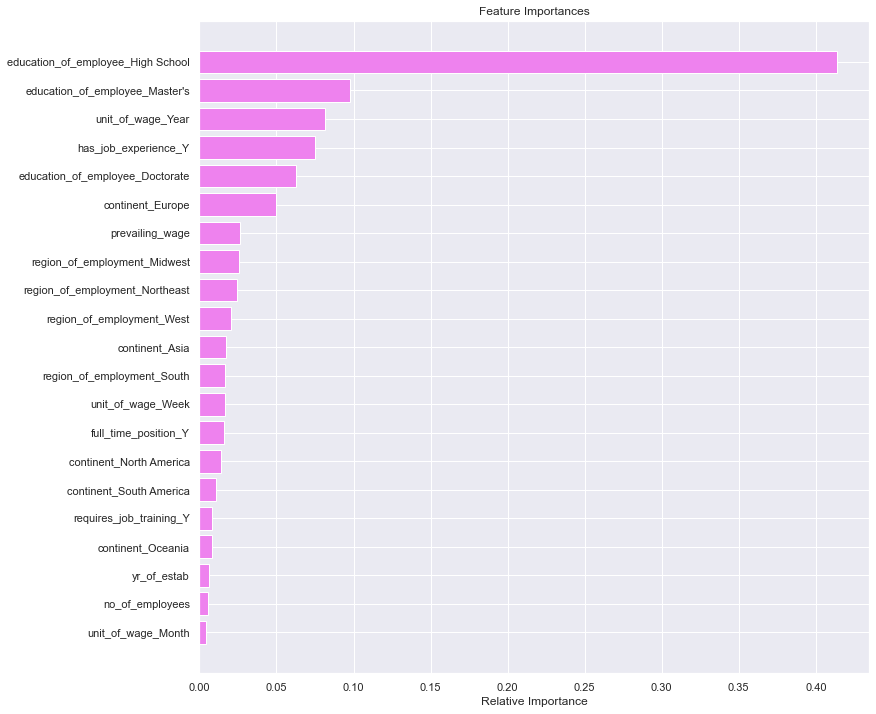

```python
feature_names = X_train.columns
importances = xgb_tuned.feature_importances_
indices = np.argsort(importances)

plt.figure(figsize=(12,12))
plt.title('Feature Importances')
plt.barh(range(len(indices)), importances[indices], color='violet', align='center')
plt.yticks(range(len(indices)), [feature_names[i] for i in indices])
plt.xlabel('Relative Importance')
plt.show()
```

## Education of employee High School, education of employee Masters and unit of wage in years and job experience plays a key role in getting the applications approved.

## Stacking Model

```python
estimators = [('bagging Classifier Tuned',bagging_estimator_tuned), ('Gradient Boosting',gbc_tuned), ('XGradientBoosting Tree',xgb_tuned)]

final_estimator = xgb_tuned

stacking_classifier= StackingClassifier(estimators=estimators,final_estimator=final_estimator)

stacking_classifier.fit(X_train,y_train)
```

```
StackingClassifier(estimators=[('bagging Classifier Tuned',
                                BaggingClassifier(max_features=0.8,
                                                  max_samples=0.7,
                                                  n_estimators=50,
                                                  random_state=1)),
                               ('Gradient Boosting',
                                GradientBoostingClassifier(init=AdaBoostClassifier(random_state=1),
                                                           max_features=0.9,
                                                           random_state=1,
                                                           subsample=0.9)),
                               ('XGradientBoosting Tree',
                                XGBClassifier(base_score=0.5, booster='gbtree',
                                              cal...
                                                 eval_metric='logloss', gamma=0,
                                                 gpu_id=-1,
                                                 grow_policy='depthwise',
                                                 importance_type=None,
                                                 interaction_constraints='',
                                                 learning_rate=0.05,
                                                 max_bin=256,
                                                 max_cat_to_onehot=4,
                                                 max_delta_step=0, max_depth=6,
                                                 max_leaves=0,
                                                 min_child_weight=1,
                                                 missing=nan,
                                                 monotone_constraints='()',
                                                 n_estimators=30, n_jobs=0,
                                                 num_parallel_tree=1,
                                                 predictor='auto',
                                                 random_state=1, reg_alpha=0,
                                                 reg_lambda=1, ...))
```

```
Training performance:
    Accuracy    Recall  Precision        F1
0  0.761774  0.877193   0.789513  0.831047
Testing performance:
    Accuracy    Recall  Precision        F1
0  0.746599  0.870323    0.77702  0.821029
```

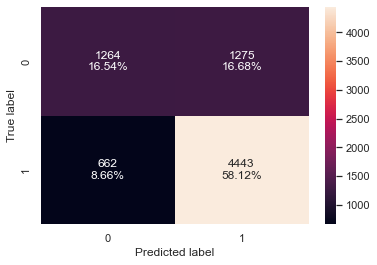

```python
#Calculating different metrics
stacking_classifier_model_train_perf=model_performance_classification_sklearn(stacking_classifier,X_train,y_train)
print("Training performance:\n",stacking_classifier_model_train_perf)
stacking_classifier_model_test_perf=model_performance_classification_sklearn(stacking_classifier,X_test,y_test)
print("Testing performance:\n",stacking_classifier_model_test_perf)

#Creating confusion matrix
confusion_matrix_sklearn(stacking_classifier,X_test,y_test)
```

## Model Performance Comparison and Conclusions

```python
# training performance comparison

models_train_comp_df = pd.concat(
    [d_tree_model_train_perf.T,dtree_estimator_model_train_perf.T,rf_estimator_model_train_perf.T,rf_tuned_model_train_perf.T,
     bagging_classifier_model_train_perf.T,bagging_estimator_tuned_model_train_perf.T,ab_classifier_model_train_perf.T,
     abc_tuned_model_train_perf.T,gb_classifier_model_train_perf.T,gbc_tuned_model_train_perf.T,xgb_classifier_model_train_perf.T,
    xgb_tuned_model_train_perf.T,stacking_classifier_model_train_perf.T],
    axis=1,
)
models_train_comp_df.columns = [
    "Decision Tree",
    "Decision Tree Estimator",
    "Random Forest Estimator",
    "Random Forest Tuned",
    "Bagging Classifier",
    "Bagging Classifier Tuned",
    "Adaboost Classifier",
    "Adabosst Classifier Tuned",
    "Gradient Boost Classifier",
    "Gradient Boost Classifier Tuned",
    "XGBoost Classifier",
    "XGBoost Classifier Tuned",
    "Stacking Classifier"]
print("Training performance comparison:")
models_train_comp_df
```

```
Training performance comparison:
```

|  | Decision Tree | Decision Tree Estimator | Random Forest Estimator | Random Forest Tuned | Bagging Classifier | Bagging Classifier Tuned | Adaboost Classifier | Adabosst Classifier Tuned | Gradient Boost Classifier | Gradient Boost Classifier Tuned | XGBoost Classifier | XGBoost Classifier Tuned | Stacking Classifier |
| --- | --- | --- | --- | --- | --- | --- | --- | --- | --- | --- | --- | --- | --- |
| Accuracy | 1.0 | 1.0 | 0.999944 | 0.668199 | 0.985198 | 0.992824 | 0.738226 | 0.754317 | 0.758802 | 0.759027 | 0.838753 | 0.759587 | 0.761774 |
| Recall | 1.0 | 1.0 | 0.999916 | 1.000000 | 0.985982 | 0.998825 | 0.887182 | 0.889365 | 0.883740 | 0.882649 | 0.931419 | 0.883740 | 0.877193 |
| Precision | 1.0 | 1.0 | 1.000000 | 0.668106 | 0.991810 | 0.990510 | 0.760688 | 0.775679 | 0.783042 | 0.783824 | 0.843482 | 0.783858 | 0.789513 |
| F1 | 1.0 | 1.0 | 0.999958 | 0.801036 | 0.988887 | 0.994650 | 0.819080 | 0.828641 | 0.830349 | 0.830306 | 0.885272 | 0.830808 | 0.831047 |

```python
# testing performance comparison

models_test_comp_df = pd.concat(
    [d_tree_model_test_perf.T,dtree_estimator_model_test_perf.T,rf_estimator_model_test_perf.T,rf_tuned_model_test_perf.T,
     bagging_classifier_model_test_perf.T,bagging_estimator_tuned_model_test_perf.T,ab_classifier_model_test_perf.T,
     abc_tuned_model_test_perf.T,gb_classifier_model_test_perf.T,gbc_tuned_model_test_perf.T,xgb_classifier_model_test_perf.T,
    xgb_tuned_model_test_perf.T,stacking_classifier_model_test_perf.T],
    axis=1,
)
models_test_comp_df.columns = [
    "Decision Tree",
    "Decision Tree Estimator",
    "Random Forest Estimator",
    "Random Forest Tuned",
    "Bagging Classifier",
    "Bagging Estimator Tuned",
    "Adaboost Classifier",
    "Adabosst Classifier Tuned",
    "Gradient Boost Classifier",
    "Gradient Boost Classifier Tuned",
    "XGBoost Classifier",
    "XGBoost Classifier Tuned",
    "Stacking Classifier"]
print("Testing performance comparison:")
models_test_comp_df
```

```
Testing performance comparison:
```

|  | Decision Tree | Decision Tree Estimator | Random Forest Estimator | Random Forest Tuned | Bagging Classifier | Bagging Estimator Tuned | Adaboost Classifier | Adabosst Classifier Tuned | Gradient Boost Classifier | Gradient Boost Classifier Tuned | XGBoost Classifier | XGBoost Classifier Tuned | Stacking Classifier |
| --- | --- | --- | --- | --- | --- | --- | --- | --- | --- | --- | --- | --- | --- |
| Accuracy | 0.664835 | 0.664835 | 0.720827 | 0.667844 | 0.691523 | 0.730508 | 0.734301 | 0.740450 | 0.744767 | 0.744505 | 0.733255 | 0.745683 | 0.746599 |
| Recall | 0.742801 | 0.742801 | 0.832125 | 0.999804 | 0.764153 | 0.869931 | 0.885015 | 0.881293 | 0.876004 | 0.874045 | 0.860725 | 0.876004 | 0.870323 |
| Precision | 0.752232 | 0.752232 | 0.768869 | 0.667888 | 0.771711 | 0.760836 | 0.757799 | 0.765527 | 0.772366 | 0.773042 | 0.767913 | 0.773301 | 0.777020 |
| F1 | 0.747487 | 0.747487 | 0.799247 | 0.800816 | 0.767913 | 0.811735 | 0.816481 | 0.819341 | 0.820927 | 0.820447 | 0.811675 | 0.821455 | 0.821029 |

- The majority of the models are overfitting the training data in terms of f1-score.
- The XGBoost tuned classifier is giving the highest f1-score on the test data.
- The staking classifier has given the second-highest test f1-score and is consistent on both precision and recall on both test and train data.

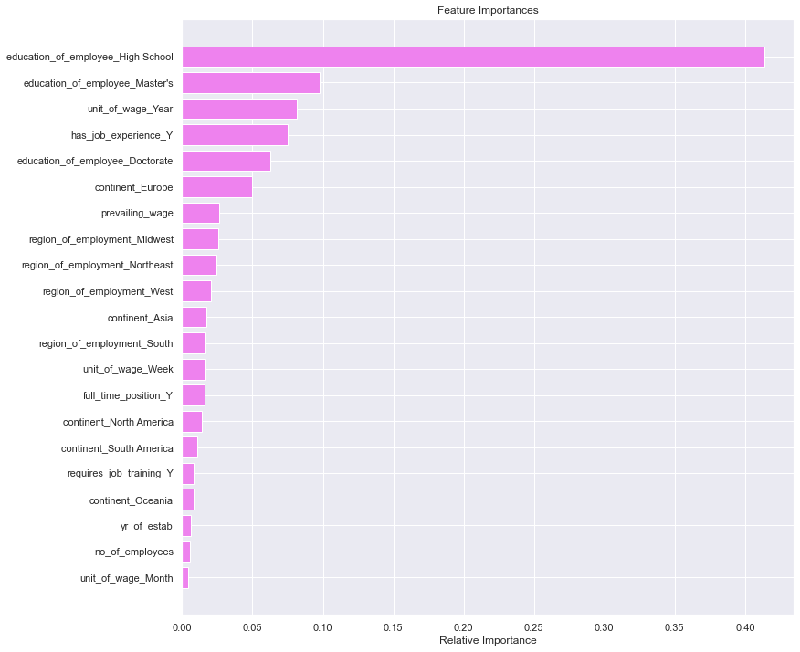

```python
feature_names = X_train.columns
importances = xgb_tuned.feature_importances_
indices = np.argsort(importances)

plt.figure(figsize=(12,12))
plt.title('Feature Importances')
plt.barh(range(len(indices)), importances[indices], color='violet', align='center')
plt.yticks(range(len(indices)), [feature_names[i] for i in indices])
plt.xlabel('Relative Importance')
plt.show()
```

Education of employee High School, education of employee Masters and unit of wage in years and job experience, education of employee Doctorate plays a key role in getting the applications Certified.

## Conclusions and Recommendations

- Based on our analysis, we can say that a application can be Certified if the applicant is

  . Education of employee High School

  . Education of employee Masters

  . Unit of wage in years

  . Prior job experience

  . Education of employee Doctorate

  . Europe continent

  . Prevailing Wage.
- OFLC should be focusing on the applicants having the above important factors.
- OFLC can focus on the applicants desired location to work - NorthEast and South areas have higher rate of approval.
- OFLC can avoid taking the applicants that are paid hourly and weekly.

## EDA

- It is a good idea to explore the data once again after manipulating it.

We are not doing any EDA again as we didnt update any columns. and no outlier treatment was done.